# HBV_Data_Analysis

```python
import pandas as pd
import matplotlib.pyplot as plt
import seaborn as sns

# Load and preprocess data
data = []
with open('all.txt', 'r') as f:
    for line in f:
        record = {}
        pairs = line.strip().split(',')
        for pair in pairs:
            if '-' in pair:
                k, v = pair.split('-', 1)
                record[k] = v
        data.append(record)
df = pd.DataFrame(data)
```

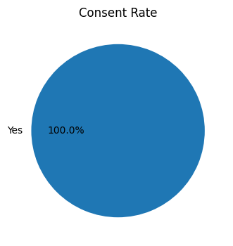

```python
# 1. Consent Rate
df['c'] = df['c'].replace({'y': 'Yes', 'n': 'No'})
plt.figure(figsize=(6,4))
df['c'].value_counts().plot(kind='pie', autopct='%1.1f%%')
plt.title('Consent Rate')
plt.ylabel('')
plt.show()
```

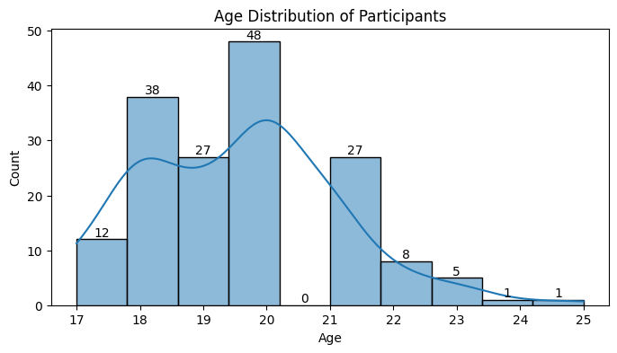

```python
import numpy as np

# 2. Age Distribution
plt.figure(figsize=(8, 4))

# Create the histogram with a kernel density estimate (KDE)
hist = sns.histplot(df['age'].astype(float), bins=10, kde=True)

# Get the counts for each bin
counts, edges = np.histogram(df['age'].astype(float), bins=10)

# Calculate the bin centers
bin_centers = 0.5 * (edges[1:] + edges[:-1])

# Annotate the counts on top of the histogram bars
for count, x in zip(counts, bin_centers):
    plt.text(x, count, str(count), ha='center', va='bottom')

plt.title('Age Distribution of Participants')
plt.xlabel('Age')
plt.ylabel('Count')
plt.show()
```

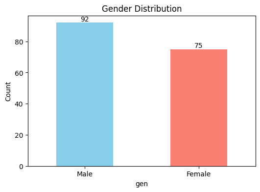

```python
# 3. Gender Distribution
plt.figure(figsize=(6, 4))

# Create the bar chart for gender distribution
gender_counts = df['gen'].value_counts()
bars = gender_counts.plot(kind='bar', color=['skyblue', 'salmon'])

plt.title('Gender Distribution')
plt.xticks([0, 1], ['Male', 'Female'], rotation=0)

# Annotate counts on top of each bar
for bar in bars.containers[0]:
    height = bar.get_height()
    plt.text(bar.get_x() + bar.get_width() / 2, height, str(int(height)), ha='center', va='bottom')

plt.ylabel('Count')
plt.show()
```

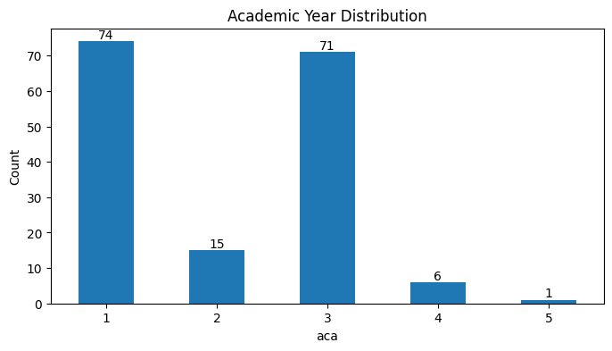

```python
# 4. Academic Year Distribution
plt.figure(figsize=(8, 4))

# Create the bar chart for academic year distribution
academic_counts = df['aca'].value_counts().sort_index()
bars = academic_counts.plot(kind='bar')

plt.title('Academic Year Distribution')
plt.xticks(rotation=0)

# Annotate counts on top of each bar
for bar in bars.containers[0]:
    height = bar.get_height()
    plt.text(bar.get_x() + bar.get_width() / 2, height, str(int(height)), ha='center', va='bottom')

plt.ylabel('Count')
plt.show()
```

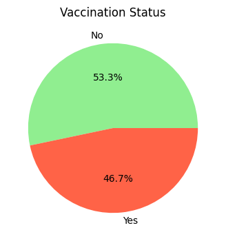

```python
# 5. Vaccination Status
plt.figure(figsize=(6,4))
df['q24'] = df['q24'].replace({'y': 'Yes', 'n': 'No'})
df['q24'].value_counts().plot(kind='pie', autopct='%1.1f%%', colors=['lightgreen', 'tomato'])
plt.title('Vaccination Status')
plt.ylabel('')
plt.show()
```

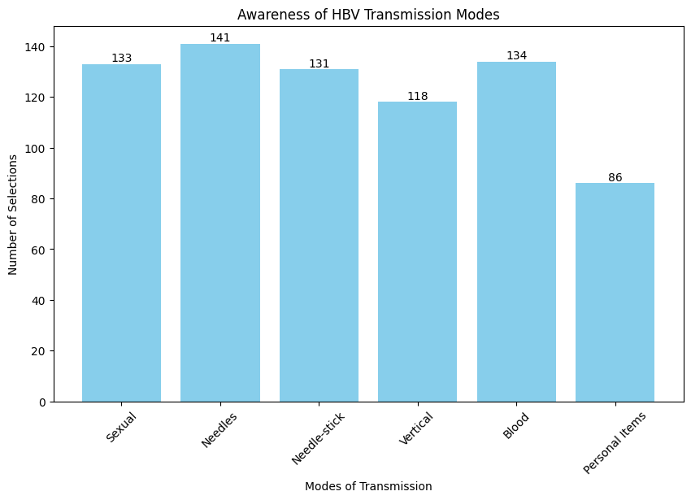

```python
# Transmission modes columns
transmission_modes = ['q3_1', 'q3_2', 'q3_3', 'q3_4', 'q3_5', 'q3_6']

# Convert all columns to numeric, coercing errors to NaN
for col in transmission_modes:
    df[col] = pd.to_numeric(df[col], errors='coerce')

labels = ['Sexual', 'Needles', 'Needle-stick', 'Vertical', 'Blood', 'Personal Items']

# Sum the frequency of responses for each transmission mode
tm_counts = df[transmission_modes].apply(lambda col: (col > 0).sum())

# Plot
plt.figure(figsize=(10, 6))
bars = plt.bar(labels, tm_counts, color='skyblue')
plt.title('Awareness of HBV Transmission Modes')
plt.ylabel('Number of Selections')
plt.xlabel('Modes of Transmission')
plt.xticks(rotation=45)

# Annotate counts on top of each bar
for bar in bars:
    height = bar.get_height()
    plt.text(bar.get_x() + bar.get_width() / 2, height, str(int(height)), ha='center', va='bottom')

plt.show()
```

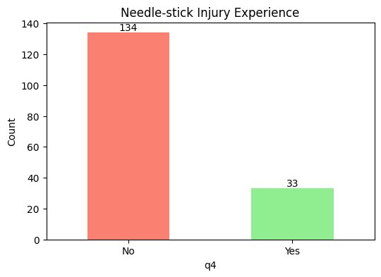

```python
# 8. Needlestick Injury Experience
plt.figure(figsize=(6, 4))

# Create the bar chart for needle-stick injury experience
injury_counts = df['q4'].value_counts()
bars = injury_counts.plot(kind='bar', color=['salmon', 'lightgreen'])

plt.title('Needle-stick Injury Experience')
plt.xticks([0, 1], ['No', 'Yes'], rotation=0)

# Annotate counts on top of each bar
for bar in bars.containers[0]:
    height = bar.get_height()
    plt.text(bar.get_x() + bar.get_width() / 2, height, str(int(height)), ha='center', va='bottom')

plt.ylabel('Count')
plt.show()
```

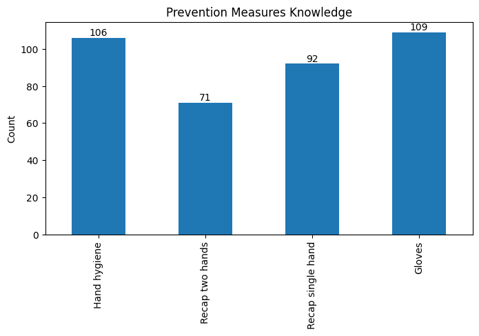

```python
# 9. Prevention Measures Knowledge
# Define the prevention measure columns
prevention_cols = ['q5_1', 'q5_2', 'q5_3', 'q5_4']

# Convert all columns to numeric, coercing errors to NaN
for col in prevention_cols:
    df[col] = pd.to_numeric(df[col], errors='coerce')

# Sum the frequency of responses for each prevention measure
prev_counts = df[prevention_cols].apply(lambda col: (col > 0).sum())

# Plot
plt.figure(figsize=(8, 4))
bars = prev_counts.plot(kind='bar')

plt.title('Prevention Measures Knowledge')
plt.xticks(ticks=range(4), labels=['Hand hygiene', 'Recap two hands', 'Recap single hand', 'Gloves'])

# Annotate counts on top of each bar
for bar in bars.containers[0]:
    height = bar.get_height()
    plt.text(bar.get_x() + bar.get_width() / 2, height, str(int(height)), ha='center', va='bottom')

plt.ylabel('Count')
plt.show()
```

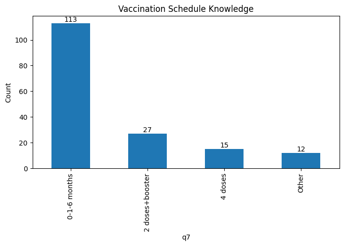

```python
# 10. Vaccination Schedule Knowledge
plt.figure(figsize=(8, 4))

# Create the bar chart for vaccination schedule knowledge
vaccination_counts = df['q7'].value_counts().sort_index()
bars = vaccination_counts.plot(kind='bar')

plt.title('Vaccination Schedule Knowledge')
plt.xticks(ticks=[0, 1, 2, 3], labels=['0-1-6 months', '2 doses+booster', '4 doses', 'Other'])

# Annotate counts on top of each bar
for bar in bars.containers[0]:
    height = bar.get_height()
    plt.text(bar.get_x() + bar.get_width() / 2, height, str(int(height)), ha='center', va='bottom')

plt.ylabel('Count')
plt.show()
```

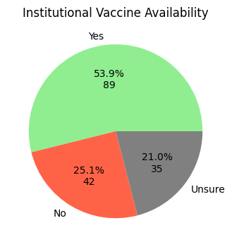

```python
# 11. Institutional Vaccine Availability
df['q31'] = df['q31'].replace({'y': 'Yes', 'n': 'No', 'u':'Unsure'})
plt.figure(figsize=(6, 4))

# Get counts for each category
vaccine_counts = df['q31'].value_counts()

# Create the pie chart with counts and percentages
plt.pie(vaccine_counts, labels=vaccine_counts.index, autopct=lambda p: f'{p:.1f}%\n{int(p * sum(vaccine_counts) / 100)}',
         colors=['lightgreen', 'tomato', 'gray'])

plt.title('Institutional Vaccine Availability')
plt.ylabel('')
plt.show()
```

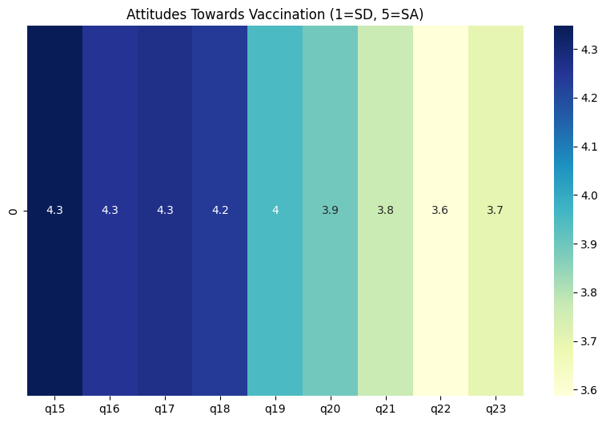

```python
# 12. Attitudes Heatmap
attitude_cols = [f'q{i}' for i in range(15,24)]
attitude_df = df[attitude_cols].apply(lambda x: x.map({'sa':5, 'a':4, 'ne':3, 'd':2, 'sd':1}))
plt.figure(figsize=(10,6))
sns.heatmap(attitude_df.mean().to_frame().T, annot=True, cmap='YlGnBu')
plt.title('Attitudes Towards Vaccination (1=SD, 5=SA)')
plt.show()
```

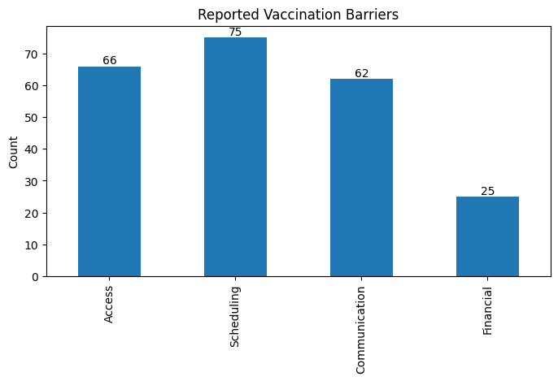

```python
# 13. Vaccination Barriers
# Define the vaccination barrier columns
barrier_cols = [f'q34_{i}' for i in range(1, 5)]

# Convert all columns to numeric, coercing errors to NaN
for col in barrier_cols:
    df[col] = pd.to_numeric(df[col], errors='coerce')

# Sum the frequency of responses for each vaccination barrier
barrier_counts = df[barrier_cols].apply(lambda col: (col > 0).sum())

# Plot
plt.figure(figsize=(8, 4))
bars = barrier_counts.plot(kind='bar')

plt.title('Reported Vaccination Barriers')
plt.xticks(ticks=range(4), labels=['Access', 'Scheduling', 'Communication', 'Financial'])

# Annotate counts on top of each bar
for bar in bars.containers[0]:
    height = bar.get_height()
    plt.text(bar.get_x() + bar.get_width() / 2, height, str(int(height)), ha='center', va='bottom')

plt.ylabel('Count')
plt.show()
```

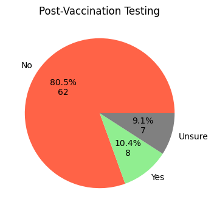

```python
# 14. Post-Vaccination Testing
plt.figure(figsize=(6, 4))

# Replace values in the column for better readability
df['q27'] = df['q27'].replace({'y': 'Yes', 'n': 'No', 'unsure': 'Unsure'})

# Get value counts for each category
post_vaccination_counts = df['q27'].value_counts()

# Create the pie chart with counts and percentages
plt.pie(post_vaccination_counts,
        labels=post_vaccination_counts.index,
        autopct=lambda p: f'{p:.1f}%\n{int(p * sum(post_vaccination_counts) / 100)}',
        colors=['tomato', 'lightgreen', 'gray'])

plt.title('Post-Vaccination Testing')
plt.ylabel('')
plt.show()
```

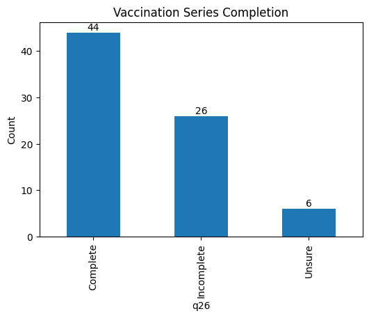

```python
# 15. Dose Completion Status
plt.figure(figsize=(6, 4))

# Create the bar chart for vaccination series completion
completion_counts = df['q26'].value_counts()
bars = completion_counts.plot(kind='bar')

plt.title('Vaccination Series Completion')
plt.xticks(ticks=[0, 1, 2], labels=['Complete', 'Incomplete', 'Unsure'])

# Annotate counts on top of each bar
for bar in bars.containers[0]:
    height = bar.get_height()
    plt.text(bar.get_x() + bar.get_width() / 2, height, str(int(height)), ha='center', va='bottom')

plt.ylabel('Count')
plt.show()
```

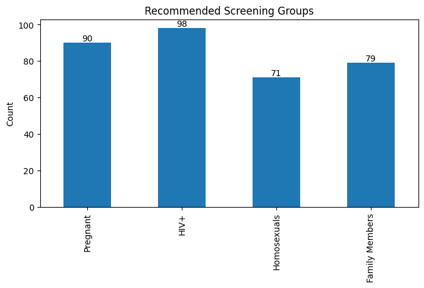

```python
# 16. Screening Recommendations
# Define the screening columns
screen_cols = ['q11_1', 'q11_2', 'q11_3', 'q11_4']

# Convert all columns to numeric, coercing errors to NaN
for col in screen_cols:
    df[col] = pd.to_numeric(df[col], errors='coerce')

# Sum the frequency of responses for each screening group
screen_counts = df[screen_cols].apply(lambda col: (col > 0).sum())

# Plot
plt.figure(figsize=(8, 4))
bars = screen_counts.plot(kind='bar')

plt.title('Recommended Screening Groups')
plt.xticks(ticks=range(4), labels=['Pregnant', 'HIV+', 'Homosexuals', 'Family Members'])

# Annotate counts on top of each bar
for bar in bars.containers[0]:
    height = bar.get_height()
    plt.text(bar.get_x() + bar.get_width() / 2, height, str(int(height)), ha='center', va='bottom')

plt.ylabel('Count')
plt.show()
```

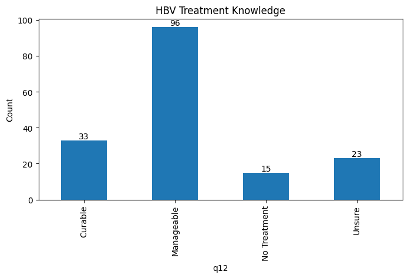

```python
# 17. Treatment Knowledge
plt.figure(figsize=(8, 4))

# Create the bar chart for HBV treatment knowledge
treatment_counts = df['q12'].value_counts().sort_index()
bars = treatment_counts.plot(kind='bar')

plt.title('HBV Treatment Knowledge')
plt.xticks(ticks=[0, 1, 2, 3], labels=['Curable', 'Manageable', 'No Treatment', 'Unsure'])

# Annotate counts on top of each bar
for bar in bars.containers[0]:
    height = bar.get_height()
    plt.text(bar.get_x() + bar.get_width() / 2, height, str(int(height)), ha='center', va='bottom')

plt.ylabel('Count')
plt.show()
```

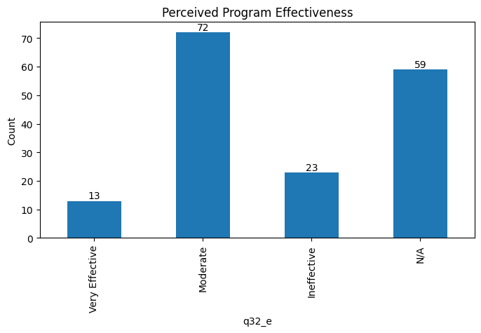

```python
# 18. Institutional Program Effectiveness
plt.figure(figsize=(8, 4))

# Create the bar chart for perceived program effectiveness
effectiveness_counts = df['q32_e'].value_counts().sort_index()
bars = effectiveness_counts.plot(kind='bar')

plt.title('Perceived Program Effectiveness')
plt.xticks(ticks=[0, 1, 2, 3], labels=['Very Effective', 'Moderate', 'Ineffective', 'N/A'])

# Annotate counts on top of each bar
for bar in bars.containers[0]:
    height = bar.get_height()
    plt.text(bar.get_x() + bar.get_width() / 2, height, str(int(height)), ha='center', va='bottom')

plt.ylabel('Count')
plt.show()
```

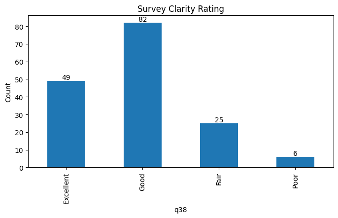

```python
# 19. Survey Feedback
plt.figure(figsize=(8, 4))

# Create the bar chart for survey clarity rating
feedback_counts = df['q38'].value_counts().sort_index()
bars = feedback_counts.plot(kind='bar')

plt.title('Survey Clarity Rating')
plt.xticks(ticks=[0, 1, 2, 3], labels=['Excellent', 'Good', 'Fair', 'Poor'])

# Annotate counts on top of each bar
for bar in bars.containers[0]:
    height = bar.get_height()
    plt.text(bar.get_x() + bar.get_width() / 2, height, str(int(height)), ha='center', va='bottom')

plt.ylabel('Count')
plt.show()
```

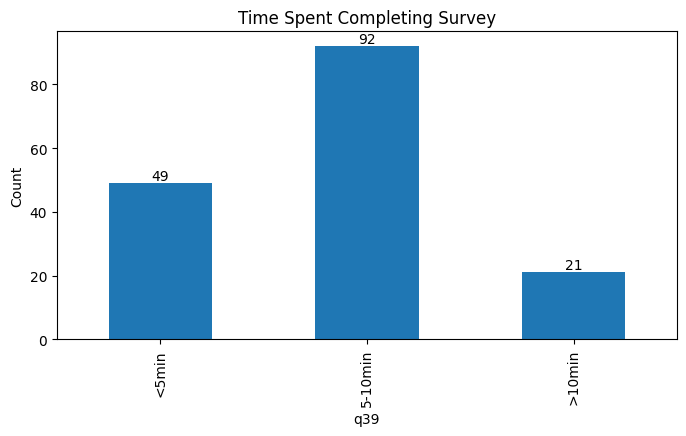

```python
# 20. Time Spent on Survey
plt.figure(figsize=(8, 4))

# Create the bar chart for time spent completing the survey
time_spent_counts = df['q39'].value_counts().sort_index()
bars = time_spent_counts.plot(kind='bar')

plt.title('Time Spent Completing Survey')
plt.xticks(ticks=[0, 1, 2], labels=['<5min', '5-10min', '>10min'])

# Annotate counts on top of each bar
for bar in bars.containers[0]:
    height = bar.get_height()
    plt.text(bar.get_x() + bar.get_width() / 2, height, str(int(height)), ha='center', va='bottom')

plt.ylabel('Count')
plt.show()
```

```python
# Create vaccination status column
df['vaccinated'] = df['q24'] == 'Yes'
df['nonvaccinated'] = df['q24'] == 'No'

# Knowledge score calculation (based on correct answers)
def calculate_knowledge(row):
    score = 0
    # q1: DNA virus (1)
    if row.get('q1') == '1': score += 1
    # q2: HBsAg(1), HBeAg(2), Anti-HBc IgM(3)
    score += sum([1 for q in ['q2_1', 'q2_2', 'q2_3'] if row.get(q) == '1'])
    # q3: All transmission modes are correct
    score += sum([1 for q in [f'q3_{i}' for i in range(1,7)] if row.get(q) == '1'])
    # q5: Correct prevention (1,3,4)
    score += sum([1 for q in ['q5_1', 'q5_3', 'q5_4'] if row.get(q) == '1'])
    # q6: Correct prevention (2,3,5)
    score += sum([1 for q in ['q6_2', 'q6_3', 'q6_5'] if row.get(q) == '1'])
    # q7: 0-1-6 months (1)
    if row.get('q7') == '1': score += 1
    # q8: Waning immunity (2)
    if row.get('q8') == '2': score += 1
    # q9: Additional doses (2)
    if row.get('q9') == '2': score += 1
    # q10: Anti-HBs (2)
    if row.get('q10') == '2': score += 1
    # q11: Correct groups (1,2,4)
    score += sum([1 for q in ['q11_1', 'q11_2', 'q11_4'] if row.get(q) == '1'])
    # q12: Manageable (2)
    if row.get('q12') == '2': score += 1
    # q13: All correct
    score += sum([1 for q in ['q13_1', 'q13_2', 'q13_3'] if row.get(q) == '1'])
    # q14: All correct
    score += sum([1 for q in ['q14_1', 'q14_2', 'q14_3'] if row.get(q) == '1'])
    return score
```

```python
df['knowledge_score'] = df.apply(calculate_knowledge, axis=1)

# Attitude score calculation
attitude_map = {'sa':5, 'a':4, 'ne':3, 'd':2, 'sd':1}
att_cols = [f'q{i}' for i in range(15,24)]
df[att_cols] = df[att_cols].replace(attitude_map)
df['attitude_score'] = df[att_cols].mean(axis=1)
```

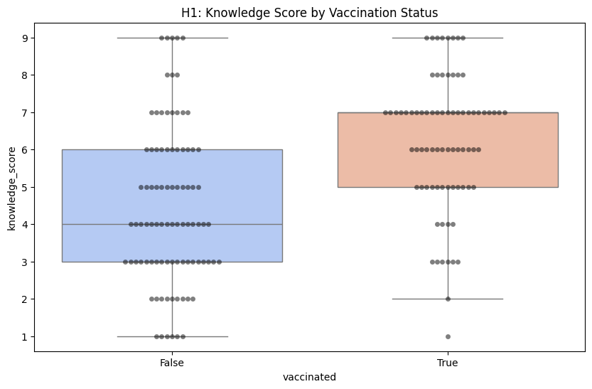

```python
# H1: Knowledge and Vaccination
plt.figure(figsize=(10,6))

# Boxplot
sns.boxplot(x='vaccinated', y='knowledge_score', data=df, showfliers=False, palette='coolwarm')

# Adding swarmplot for individual data points
sns.swarmplot(x='vaccinated', y='knowledge_score', data=df, color='black', alpha=0.5)

plt.title('H1: Knowledge Score by Vaccination Status')
plt.show()
```

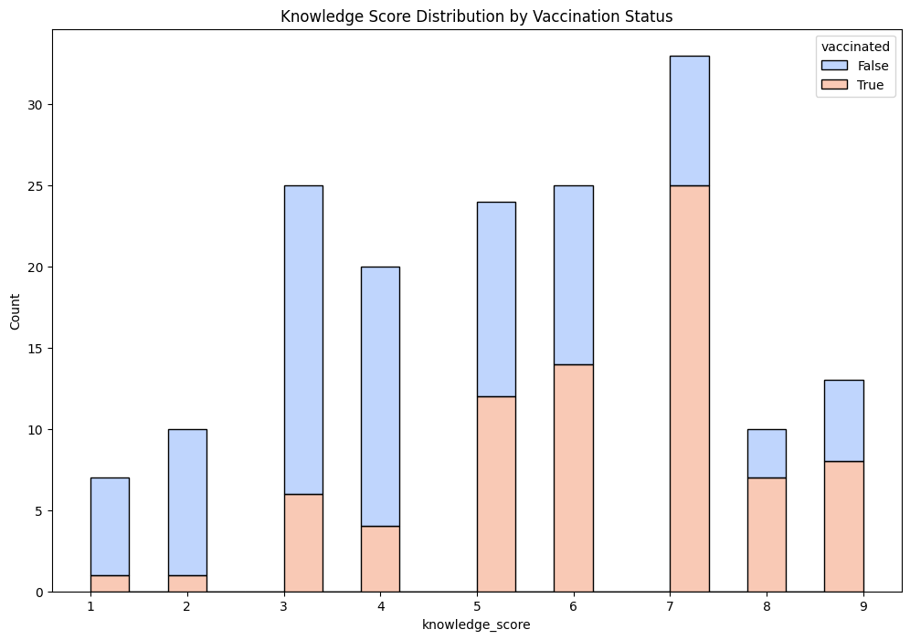

```python
plt.figure(figsize=(12, 8))
sns.histplot(data=df, x='knowledge_score', hue='vaccinated',
             multiple='stack', palette='coolwarm', bins=20)
plt.title('Knowledge Score Distribution by Vaccination Status')
plt.show()
```

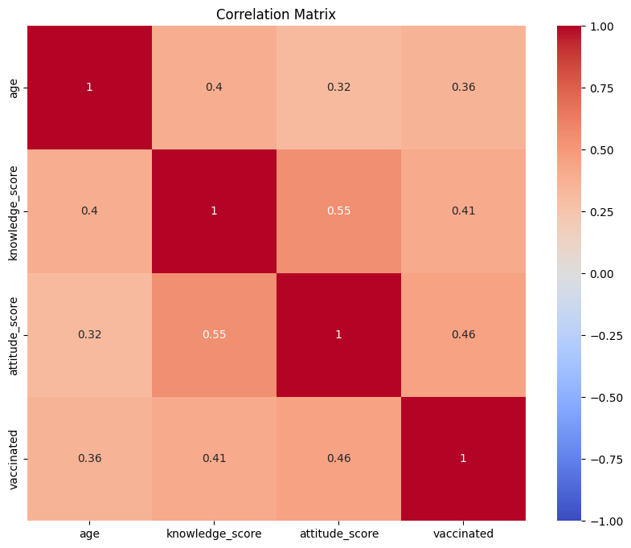

```python
# Correlation heatmap
corr_matrix = df[['age', 'knowledge_score', 'attitude_score',
                 'vaccinated']].corr()
plt.figure(figsize=(10, 8))
sns.heatmap(corr_matrix, annot=True, cmap='coolwarm', vmin=-1, vmax=1)
plt.title('Correlation Matrix')
plt.show()
```

```python
# H1: Knowledge vs Vaccination
from sklearn.preprocessing import StandardScaler
scaler = StandardScaler()
X = scaler.fit_transform(df[['knowledge_score']])
y = df['vaccinated'].astype(int)
model = LogisticRegression()
model.fit(X, y)
print(f"H1 Odds Ratio: {np.exp(model.coef_[0][0]):.2f}")
```

```
H1 Odds Ratio: 2.49
```

```python
from scipy.stats import ttest_ind

# Separate the knowledge scores based on vaccination status
vaccinated_knowledge = df[df['vaccinated'] == True]['knowledge_score']
non_vaccinated_knowledge = df[df['vaccinated'] == False]['knowledge_score']

# Perform t-test
t_stat, p_value = ttest_ind(vaccinated_knowledge, non_vaccinated_knowledge)

print(f'T-statistic: {t_stat}, P-value: {p_value}')
```

```
T-statistic: 5.762257573976278, P-value: 3.9731570850219614e-08
```

# T-test Results

## T-statistic: 5.76

### Interpretation:

- **T-statistic**: The value of 5.76 is quite large, indicating a strong difference in knowledge scores between the vaccinated and non-vaccinated groups.
- **P-value**: The P-value of $$ 3.973 \times 10^{-8} $$ is extremely small and much less than the typical threshold of 0.05. This suggests that the difference in knowledge scores between the vaccinated and non-vaccinated groups is statistically significant.

As a result, I can confidently reject the null hypothesis and conclude that there is a significant difference in knowledge scores based on vaccination status.

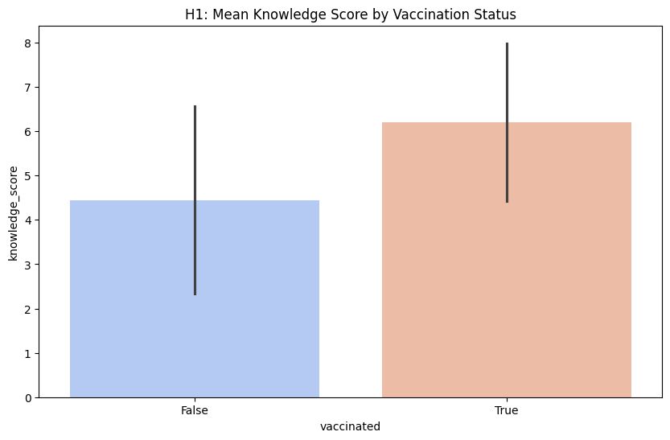

```python
plt.figure(figsize=(10,6))
sns.barplot(x='vaccinated', y='knowledge_score', data=df, ci='sd', palette='coolwarm')
plt.title('H1: Mean Knowledge Score by Vaccination Status')
plt.show()
```

```python
# Create a binary vaccination column (1 for vaccinated, 0 for not)
df['vaccinated_binary'] = df['vaccinated'].astype(int)

# Compute correlation
correlation = df['knowledge_score'].corr(df['vaccinated_binary'])
print(f'Correlation between knowledge score and vaccination status: {correlation}')
```

```
Correlation between knowledge score and vaccination status: 0.40929541978533673
```

# Correlation

### Interpretation:

- The **correlation coefficient** of 0.41 indicates a moderate positive correlation between knowledge scores and vaccination status.
- This suggests that individuals with higher knowledge about Hepatitis-B tend to have a higher likelihood of being vaccinated.
- However, the correlation is not very strong (e.g., not close to 1 or -1), so while there is an association, it is not perfectly linear.

Based on this, I can conclude that there is a moderate relationship between knowledge scores and vaccination status, but it’s not a perfect one.

```python
import statsmodels.api as sm

# Add constant for intercept
X = sm.add_constant(df['knowledge_score'])
y = df['vaccinated_binary']

# Fit the logistic regression model
model = sm.Logit(y, X)
result = model.fit()

# Display the results
print(result.summary())
```

```
Optimization terminated successfully.
         Current function value: 0.601269
         Iterations 5
                           Logit Regression Results
==============================================================================
Dep. Variable:      vaccinated_binary   No. Observations:                  167
Model:                          Logit   Df Residuals:                      165
Method:                           MLE   Df Model:                            1
Date:                Thu, 03 Apr 2025   Pseudo R-squ.:                  0.1298
Time:                        01:49:53   Log-Likelihood:                -100.41
converged:                       True   LL-Null:                       -115.39
Covariance Type:            nonrobust   LLR p-value:                 4.405e-08
===================================================================================
                      coef    std err          z      P>|z|      [0.025      0.975]
-----------------------------------------------------------------------------------
const              -2.4900      0.513     -4.855      0.000      -3.495      -1.485
knowledge_score     0.4412      0.089      4.942      0.000       0.266       0.616
===================================================================================
```

# Logistic Regression Results

You performed a logistic regression to predict vaccination status based on knowledge score. Here's how to interpret the results:

### Key Results from Logistic Regression:

- **Coefficient (knowledge_score):** 0.441
- **P-value for knowledge_score:** $$ P = 0.000 $$
- **Pseudo R-squared:** 0.1298

### Interpretation:

- **Knowledge Score Coefficient (0.441):** This positive coefficient indicates that as the knowledge score increases, the log-odds of being vaccinated also increase. In simpler terms, higher knowledge is associated with a higher likelihood of being vaccinated.
- **Odds Ratio (OR):** $$ \text{OR} = e^{0.441} \approx 1.554 $$

  For each one-point increase in the knowledge score, the odds of being vaccinated increase by about 55%.
- **P-value for knowledge_score:** The P-value is extremely small ($$ P = 0.000 $$), indicating that the knowledge score is a statistically significant predictor of vaccination status.
- **Pseudo R-squared (0.1298):** This is a measure of how well the model fits the data, similar to R-squared in linear regression. A value of 0.1298 suggests that about 13% of the variance in vaccination status can be explained by knowledge score. This is a moderate fit, but the model could likely be improved with more features or data.

Based on these results, I can conclude that knowledge score is a significant predictor of vaccination status, and while the model explains some of the variance, there's still room for improvement.

# Conclusion

Based on the analysis, I have found the following:

In conclusion, the analysis suggests that knowledge about Hepatitis-B plays a significant role in vaccination status, with higher knowledge associated with a greater likelihood of being vaccinated.

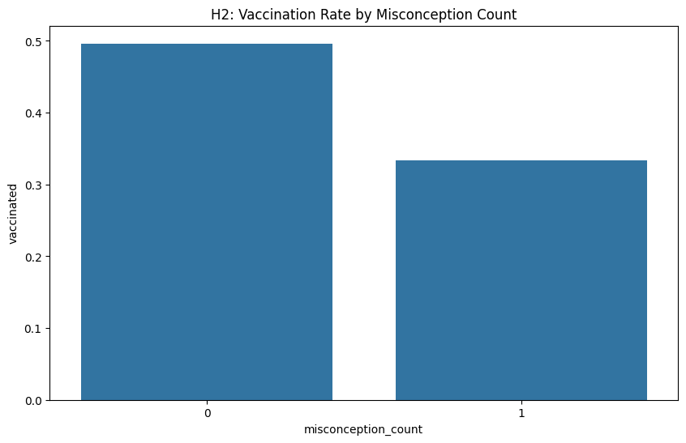

```python
# H2: Misconceptions and Vaccination
misconceptions = [
    ('q2_4', 'HBV curable'),
    ('q5_2', 'Recap with two hands'),
    ('q6_1', 'Food transmission'),
    ('q6_4', 'Utensil sharing'),
    ('q11_3', 'Homosexuals screening')
]

df['misconception_count'] = sum([df[q] == '1' for q, _ in misconceptions])
plt.figure(figsize=(10,6))
sns.barplot(x='misconception_count', y='vaccinated', data=df, ci=None)
plt.title('H2: Vaccination Rate by Misconception Count')
plt.show()
```

# Bar Graph

The small difference of **0.15** in the bar values suggests that the misconception count has minimal impact on vaccination rates.

This indicates that the number of misconceptions may not be a strong factor in vaccination status, and other factors could be influencing vaccination rates more than misconceptions alone.

```python
import statsmodels.api as sm

# Add constant for intercept
X = sm.add_constant(df['misconception_count'])
y = df['vaccinated']

# Fit the logistic regression model
model = sm.Logit(y, X)
result = model.fit()

# Display the results
print(result.summary())
```

```
Optimization terminated successfully.
         Current function value: 0.682952
         Iterations 4
                           Logit Regression Results
==============================================================================
Dep. Variable:             vaccinated   No. Observations:                  167
Model:                          Logit   Df Residuals:                      165
Method:                           MLE   Df Model:                            1
Date:                Thu, 03 Apr 2025   Pseudo R-squ.:                 0.01161
Time:                        01:50:21   Log-Likelihood:                -114.05
converged:                       True   LL-Null:                       -115.39
Covariance Type:            nonrobust   LLR p-value:                    0.1016
=======================================================================================
                          coef    std err          z      P>|z|      [0.025      0.975]
---------------------------------------------------------------------------------------
const                  -0.0146      0.171     -0.085      0.932      -0.350       0.320
misconception_count    -0.6785      0.423     -1.603      0.109      -1.508       0.151
=======================================================================================
```

# Logistic Regression (Single Variable - Misconception Count)

### Summary of Results:

- **Coefficient for misconception_count:** -0.6785
- **P-value for misconception_count:** 0.109

### Interpretation:

The negative coefficient for misconception_count is not statistically significant (P-value = 0.109)(lack of significance is (P-value > 0.05)).

This suggests that misconception count is not a significant predictor of vaccination status, and the relationship between misconceptions and vaccination is too weak to draw a meaningful conclusion.

```python
from scipy.stats import pointbiserialr

# Calculate the point-biserial correlation
corr, p_value = pointbiserialr(df['misconception_count'], df['vaccinated'])

print(f'Point-biserial correlation: {corr}, P-value: {p_value}')
```

```
Point-biserial correlation: -0.12543293577048734, P-value: 0.10627572599271369
```

# Point-Biserial Correlation

### Results:

- **Correlation:** -0.1254
- **P-value:** 0.106

### Interpretation:

The correlation of -0.1254 is close to 0, indicating almost no linear relationship between misconception count and vaccination status. The P-value (0.106) is greater than 0.05, suggesting the correlation is not statistically significant.

This supports the logistic regression result, showing that misconceptions are not strongly associated with vaccination status.

```python
# Additional predictors could be 'knowledge_score', 'age', 'gender', etc.
X = sm.add_constant(df[['misconception_count', 'knowledge_score']])  # Example with knowledge score
model = sm.Logit(y, X)
result = model.fit()

print(result.summary())
```

```
Optimization terminated successfully.
         Current function value: 0.599935
         Iterations 5
                           Logit Regression Results
==============================================================================
Dep. Variable:             vaccinated   No. Observations:                  167
Model:                          Logit   Df Residuals:                      164
Method:                           MLE   Df Model:                            2
Date:                Thu, 03 Apr 2025   Pseudo R-squ.:                  0.1318
Time:                        01:50:27   Log-Likelihood:                -100.19
converged:                       True   LL-Null:                       -115.39
Covariance Type:            nonrobust   LLR p-value:                 2.495e-07
=======================================================================================
                          coef    std err          z      P>|z|      [0.025      0.975]
---------------------------------------------------------------------------------------
const                  -2.3836      0.534     -4.467      0.000      -3.429      -1.338
misconception_count    -0.3068      0.462     -0.664      0.507      -1.213       0.599
knowledge_score         0.4313      0.090      4.782      0.000       0.255       0.608
=======================================================================================
```

# Logistic Regression (Multiple Variables)

### Summary of Results:

- **Coefficient for misconception_count:** -0.3068 (not significant, P-value = 0.507)
- **Coefficient for knowledge_score:** 0.4313 (significant, P-value = 0.000)
- **P-value for overall model:** 2.495e-07 (model is significant)

### Interpretation:

# Summary of Findings

- **Misconception count** does not significantly affect vaccination status, both in univariate and multivariate models.
- **Knowledge score** is a strong and significant predictor of vaccination status, as shown in the t-test and logistic regression results.

Hence I conclude that there is no big corelation between vaccination and Misconception about it.

**The H2 is null or false not significant**

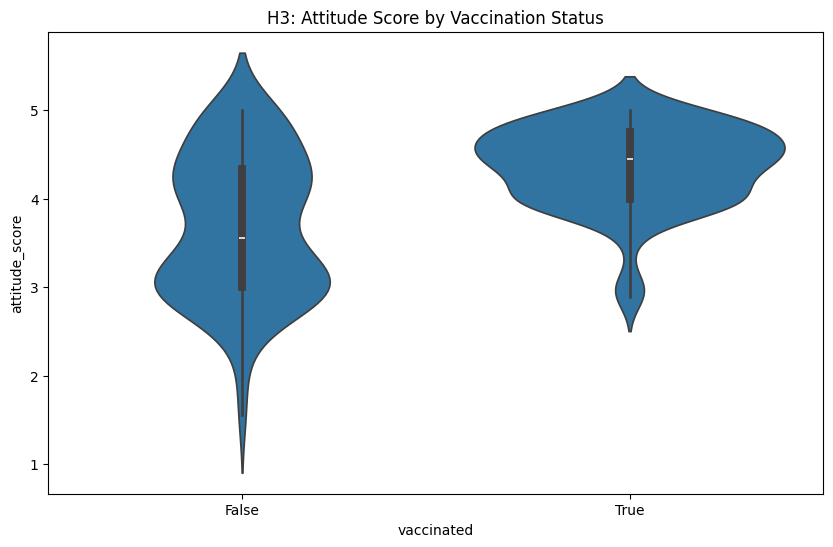

```python
# H3: Attitudes and Vaccination
plt.figure(figsize=(10,6))
sns.violinplot(x='vaccinated', y='attitude_score', data=df)
plt.title('H3: Attitude Score by Vaccination Status')
plt.show()
```

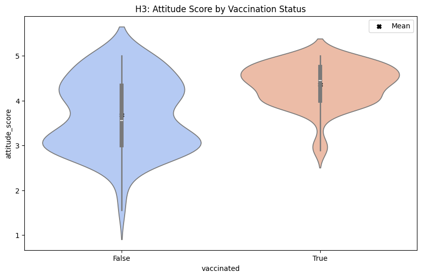

```python
plt.figure(figsize=(10,6))
sns.violinplot(x='vaccinated', y='attitude_score', data=df, palette='coolwarm')

# Add means
means = df.groupby('vaccinated')['attitude_score'].mean()
plt.scatter(means.index, means.values, color='black', marker='X', label='Mean')

plt.title('H3: Attitude Score by Vaccination Status')
plt.legend()
plt.show()
```

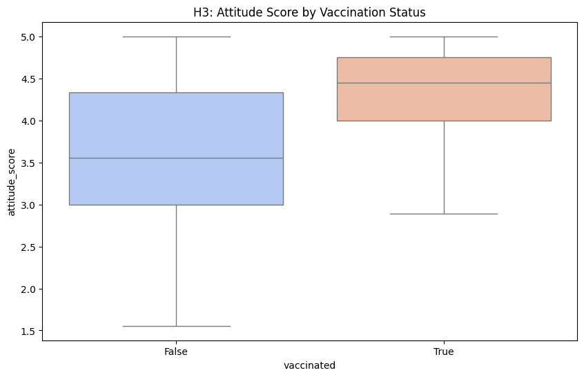

```python
plt.figure(figsize=(10,6))
sns.boxplot(x='vaccinated', y='attitude_score', data=df, palette='coolwarm')
plt.title('H3: Attitude Score by Vaccination Status')
plt.show()
```

# Observation

From my observation, the shape of the violin plot differs noticeably between vaccinated and non-vaccinated individuals, and the boxplot's median suggests that vaccinated individuals tend to have a higher attitude score.

These visual patterns support the hypothesis that positive vaccine attitudes correlate with higher vaccination rates, but I'll confirm this with the statistical analysis I ran.

```python
from scipy.stats import ttest_ind

# Separate vaccinated and non-vaccinated groups
vaccinated = df[df['vaccinated'] == 1]['attitude_score']
non_vaccinated = df[df['vaccinated'] == 0]['attitude_score']

# Perform t-test
t_stat, p_value = ttest_ind(vaccinated, non_vaccinated)

print(f"T-statistic: {t_stat}")
print(f"P-value: {p_value}")
```

```
T-statistic: 6.573752980110895
P-value: 6.246264760965111e-10
```

# T-test Results

- **T-statistic:** 6.57
- **P-value:** $$ 6.246 \times 10^{-10} $$

### Interpretation:

The T-statistic of 6.57 shows a large difference in attitude scores between vaccinated and non-vaccinated groups. The small P-value (much less than 0.05) indicates that this difference is statistically significant.

Supporting the hypothesis that positive vaccine attitudes are associated with higher vaccination rates.

```python
import statsmodels.api as sm

# Prepare the data
X = sm.add_constant(df['attitude_score'])  # Add constant for intercept
y = df['vaccinated']

# Fit logistic regression model
model = sm.Logit(y, X)
result = model.fit()

# Show results
print(result.summary())
```

```
Optimization terminated successfully.
         Current function value: 0.573152
         Iterations 6
                           Logit Regression Results
==============================================================================
Dep. Variable:             vaccinated   No. Observations:                  167
Model:                          Logit   Df Residuals:                      165
Method:                           MLE   Df Model:                            1
Date:                Thu, 03 Apr 2025   Pseudo R-squ.:                  0.1705
Time:                        01:50:45   Log-Likelihood:                -95.716
converged:                       True   LL-Null:                       -115.39
Covariance Type:            nonrobust   LLR p-value:                 3.537e-10
==================================================================================
                     coef    std err          z      P>|z|      [0.025      0.975]
----------------------------------------------------------------------------------
const             -6.4703      1.211     -5.342      0.000      -8.844      -4.096
attitude_score     1.5607      0.290      5.384      0.000       0.993       2.129
==================================================================================
```

# Logistic Regression Results

- **Coefficient for attitude_score:** 1.5607
- **P-value:** 0.000(3.537e-10) (significant)

### Interpretation:

The positive coefficient of 1.5607 indicates that as the attitude score increases, the likelihood of vaccination increases. Specifically, each 1-unit increase in attitude score raises the log-odds of being vaccinated by 1.56.

The P-value of 0.000 confirms that this relationship is **statistically significant**, making attitude score a strong predictor of vaccination status.

```python
from scipy.stats import pointbiserialr

# Calculate point-biserial correlation
corr, p_value = pointbiserialr(df['attitude_score'], df['vaccinated'])

print(f"Point-biserial correlation: {corr}")
print(f"P-value: {p_value}")
```

```
Point-biserial correlation: 0.4584632327960545
P-value: 4.651978982717609e-10
```

# Point-Biserial Correlation

- **Correlation:** 0.4584
- **P-value:** $$ 4.652 \times 10^{-10} $$

### Interpretation:

The correlation of 0.4584 indicates a moderate positive relationship between attitude score and vaccination status.

The small P-value (< 0.05) confirms that this correlation is **statistically significant**, meaning that as attitude score increases, the likelihood of being vaccinated also increases.

# Conclusion

### Visuals:

Both the violin plot and boxplot show that vaccinated individuals tend to have more positive and consistent attitudes towards vaccination.

### Statistical Tests:

- The T-test confirms that the difference in attitude scores between vaccinated and non-vaccinated groups is significant.
- Logistic regression shows that attitude score is a strong predictor of vaccination status, with a positive relationship.
- The point-biserial correlation quantifies this positive relationship, indicating that more positive attitudes are moderately correlated with higher vaccination rates.

**All of this supports the hypothesis(H3) that positive vaccine attitudes directly correlate with vaccination status.**

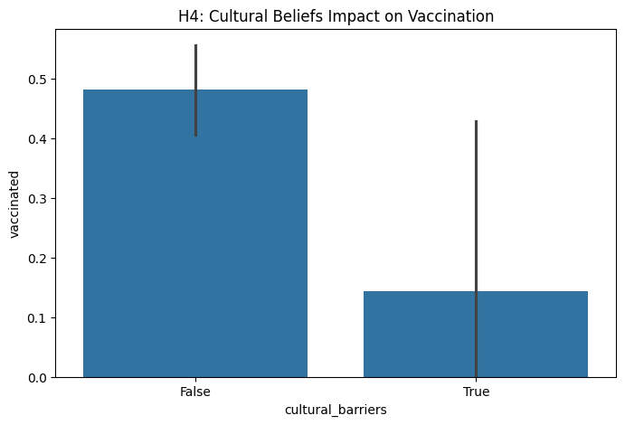

```python
# H4: Cultural Beliefs and Vaccination
df['cultural_barriers'] = df['q29_6'] == '6'
plt.figure(figsize=(8,5))
sns.barplot(x='cultural_barriers', y='vaccinated', data=df)
plt.title('H4: Cultural Beliefs Impact on Vaccination')
plt.show()
```

**Cannot't understand/visualize much from it will use Violin plot instead**

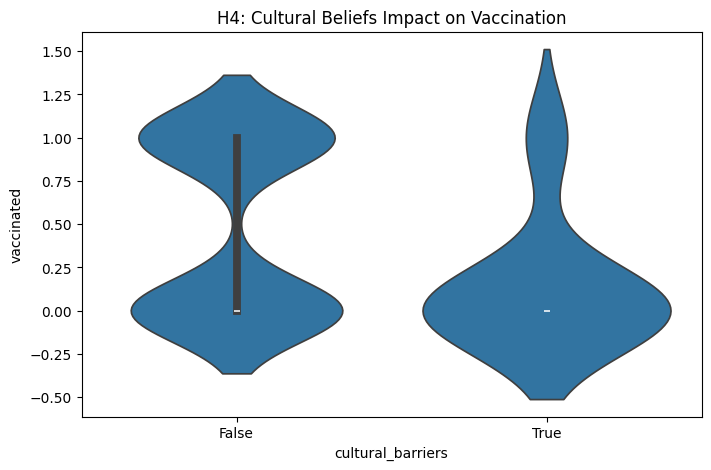

```python
plt.figure(figsize=(8, 5))
sns.violinplot(x='cultural_barriers', y='vaccinated', data=df)
plt.title('H4: Cultural Beliefs Impact on Vaccination')
plt.show()
```

# Violin Plot Interpretation

the Chi-square test(which we do later) didn’t find a significant result.

Therefore, we must be cautious about drawing strong conclusions about cultural beliefs' impact on vaccination uptake.

Other factors, such as personal beliefs, might also be involved. As our question was having **Personal or cultural/religious beliefs**

```python
from scipy.stats import chi2_contingency

# Create contingency table
contingency_table = pd.crosstab(df['cultural_barriers'], df['vaccinated'])

# Perform Chi-Square test
chi2, p_value, dof, expected = chi2_contingency(contingency_table)

print(f"Chi-Square Statistic: {chi2}")
print(f"P-value: {p_value}")
```

```
Chi-Square Statistic: 1.8755507045622912
P-value: 0.17084070205035237
```

# Chi-Square Test

- **Chi-Square Statistic:** 1.875
- **P-value:** 0.170

### Interpretation:

The P-value of 0.170 is much higher than the 0.05 threshold, indicating no statistically significant association between cultural barriers and vaccination status.

This suggests that cultural barriers, as defined in my data (using the q29_6 == '6' condition), do not significantly influence vaccination uptake.

```python
# Make sure 'cultural_barriers' is binary (0 or 1)
df['cultural_barriers'] = df['cultural_barriers'].astype(int)

# Check for missing values and handle them (e.g., fill with 0 or drop rows)
df = df.dropna(subset=['cultural_barriers', 'vaccinated'])  # Or df.fillna(0)

# Logistic Regression model
import statsmodels.api as sm

# Prepare the data
X = sm.add_constant(df['cultural_barriers'])  # Add constant for intercept
y = df['vaccinated']

# Fit logistic regression model
model = sm.Logit(y, X)
result = model.fit()

# Show results
print(result.summary())
```

```
Optimization terminated successfully.
         Current function value: 0.680610
         Iterations 6
                           Logit Regression Results
==============================================================================
Dep. Variable:             vaccinated   No. Observations:                  167
Model:                          Logit   Df Residuals:                      165
Method:                           MLE   Df Model:                            1
Date:                Thu, 03 Apr 2025   Pseudo R-squ.:                 0.01500
Time:                        01:51:05   Log-Likelihood:                -113.66
converged:                       True   LL-Null:                       -115.39
Covariance Type:            nonrobust   LLR p-value:                   0.06278
=====================================================================================
                        coef    std err          z      P>|z|      [0.025      0.975]
-------------------------------------------------------------------------------------
const                -0.0750      0.158     -0.474      0.635      -0.385       0.235
cultural_barriers    -1.7167      1.092     -1.573      0.116      -3.856       0.423
=====================================================================================
```

# Logistic Regression Analysis

Cultural barriers do not significantly influence vaccination status in from the dataset. The P-value (0.116) shows no strong evidence of an association.

The model fit is weak, with a low Pseudo R-squared and a non-significant LLR P-value, **suggesting that other factors not included in the model might better explain vaccination status than cultural barriers alone.**

**Since the Chi-square test and Logistic Regression Analysis didn't show significant results we can conclude that Cultural Barrier is not significant.**

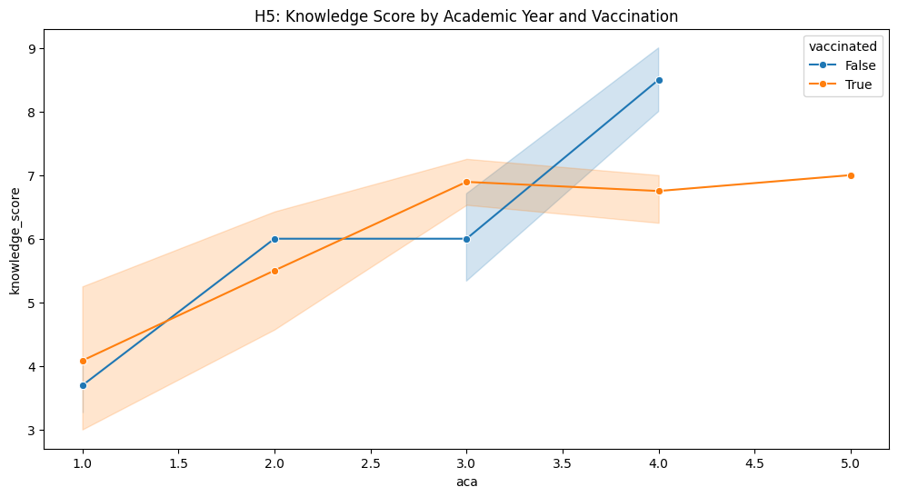

```python
# H5: Academic Year Analysis
df['aca'] = df['aca'].astype(float)
plt.figure(figsize=(12,6))
sns.lineplot(x='aca', y='knowledge_score', hue='vaccinated', data=df, marker='o')
plt.title('H5: Knowledge Score by Academic Year and Vaccination')
plt.show()
```

# Visualizing the Plot :

It is seen that **Knowledge Scores** increases with the academic Year.

**And since Knowledge was Positively related to Vaccination in H1 hypothesis and Proved**

**Thus according to Plot Academic Year has indirect Statistic significance on Vaccination status**

> Althrough the graph is irregular due to imbalance in dataset especially the 2nd year students have not responded well we have only 15 response of them similar is the case with the 4th(final year) and intern students

```python
# Logistic Regression: Modeling Vaccination Status based on Academic Year
import statsmodels.api as sm

# Defining the independent variable (aca) and dependent variable (vaccinated)
X = df[['aca']]  # We can add other predictors like 'knowledge_score' here if needed but will avoid due to less time
y = df['vaccinated'].astype(int)  # Ensure vaccinated is binary

# Add a constant term for intercept
X = sm.add_constant(X)

# Fit the logistic regression model
model = sm.Logit(y, X)
result = model.fit()

# Print the summary of the regression results
print(result.summary())
```

```
Optimization terminated successfully.
         Current function value: 0.573326
         Iterations 5
                           Logit Regression Results
==============================================================================
Dep. Variable:             vaccinated   No. Observations:                  167
Model:                          Logit   Df Residuals:                      165
Method:                           MLE   Df Model:                            1
Date:                Thu, 03 Apr 2025   Pseudo R-squ.:                  0.1703
Time:                        01:51:13   Log-Likelihood:                -95.745
converged:                       True   LL-Null:                       -115.39
Covariance Type:            nonrobust   LLR p-value:                 3.644e-10
==============================================================================
                 coef    std err          z      P>|z|      [0.025      0.975]
------------------------------------------------------------------------------
const         -2.3067      0.423     -5.458      0.000      -3.135      -1.478
aca            1.0364      0.181      5.735      0.000       0.682       1.391
==============================================================================
```

# Logistic Regression

The logistic regression results suggest that academic year (aca) is a significant predictor of vaccination status.

### Key Points:

- **Coefficient for aca:** 1.0364. As the academic year increases, the odds of being vaccinated also increase, meaning students in higher academic years are more likely to be vaccinated.
- **P-value for aca:** 0.000. Since the P-value is less than 0.05, I can reject the null hypothesis and conclude that academic year is statistically significantly associated with vaccination status.
- **Pseudo R-squared:** 0.1703. This indicates that academic year explains 17% of the variation in vaccination status.

### Interpretation:

The higher the academic year, the more likely students are to be vaccinated. This relationship is statistically significant.

```python
from scipy.stats import chi2_contingency

# Create a contingency table for Chi-Square test
contingency_table = pd.crosstab(df['aca'], df['vaccinated'])

# Perform the Chi-Square test
chi2_stat, p_val, dof, expected = chi2_contingency(contingency_table)

print("Chi-Square Statistic:", chi2_stat)
print("P-value:", p_val)
print("Degrees of Freedom:", dof)
print("Expected Frequencies:", expected)
```

```
Chi-Square Statistic: 53.676151304383616
P-value: 6.151925253211415e-11
Degrees of Freedom: 4
Expected Frequencies: [[39.43712575 34.56287425]
 [ 7.99401198  7.00598802]
 [37.83832335 33.16167665]
 [ 3.19760479  2.80239521]
 [ 0.53293413  0.46706587]]
```

# Chi-Square Test

The Chi-Square test evaluates the relationship between academic year and vaccination status by comparing observed and expected frequencies.

### Key Points from it:

- **Chi-Square Statistic:** 53.67. This measures the difference between observed and expected frequencies.
- **P-value:** 6.151e-011. Since the P-value is much smaller than 0.05, I can reject the null hypothesis and conclude that there is a relationship between academic year and vaccination status.
- **Degrees of Freedom:** 4. This is based on the 5 categories in academic year.
- **Expected Frequencies:** The table shows the expected counts of vaccinated and non-vaccinated students in each academic year group.

### Interpretation:

There is a statistically significant relationship between academic year and vaccination status, meaning vaccination status differs across academic years.

```python
from scipy.stats import ttest_ind

# Create a new column to represent vaccination status as binary
df['vaccinated_binary'] = df['vaccinated'].astype(int)

# Initialize an empty dictionary to store the results
t_test_results = {}

# Loop over each unique academic year
for aca_year in df['aca'].unique():
    # Filter data for each academic year
    year_data = df[df['aca'] == aca_year]

    # Separate vaccinated and non-vaccinated data for this year
    vaccinated_data = year_data[year_data['vaccinated_binary'] == 1]['knowledge_score']
    non_vaccinated_data = year_data[year_data['vaccinated_binary'] == 0]['knowledge_score']

    # Perform the T-test
    t_stat, p_val = ttest_ind(vaccinated_data, non_vaccinated_data, nan_policy='omit')

    # Store the result
    t_test_results[aca_year] = {'t-statistic': t_stat, 'p-value': p_val}

# Display the T-test results
for aca_year, result in t_test_results.items():
    print(f"Academic Year: {aca_year}, T-statistic: {result['t-statistic']}, P-value: {result['p-value']}")
```

```
Academic Year: 3.0, T-statistic: 2.365312187266337, P-value: 0.020831200503432457
Academic Year: 4.0, T-statistic: -3.6147844564602556, P-value: 0.022460937500000003
Academic Year: 2.0, T-statistic: -0.270356005070928, P-value: 0.7911309274137195
Academic Year: 1.0, T-statistic: 0.7005622326623591, P-value: 0.4858340434342564
Academic Year: 5.0, T-statistic: nan, P-value: nan
```